# 第2课 R 数据类型与数据结构 习题答案

顶刊研习社

Li Zongzhang

2023-10-18

# 习题1

```r
# Salaries在包carData中
# install.packages("carData")
library(carData)
data(Salaries)

library(tidyverse)
```

## 1.1

1.1 查看数据框carData::Salaries，数据框Salaries的每一列属于哪种数据类型？

rank: factor 因子型

discipline: factor 因子型

yrs.since.phd: integer 整数型

yrs.service: integer 整数型

sex: 因子型

salary: integer 整数型

```r
str(Salaries)
```

```
'data.frame':   397 obs. of  6 variables:
 $ rank         : Factor w/ 3 levels "AsstProf","AssocProf",..: 3 3 1 3 3 2 3 3 3 3 ...
 $ discipline   : Factor w/ 2 levels "A","B": 2 2 2 2 2 2 2 2 2 2 ...
 $ yrs.since.phd: int  19 20 4 45 40 6 30 45 21 18 ...
 $ yrs.service  : int  18 16 3 39 41 6 23 45 20 18 ...
 $ sex          : Factor w/ 2 levels "Female","Male": 2 2 2 2 2 2 2 2 2 1 ...
 $ salary       : int  139750 173200 79750 115000 141500 97000 175000 147765 119250 129000 ...
```

## 1.2

1.2 数据框Salaries中的rank，这个因子有几个水平？因子水平的顺序是什么？

三个水平，顺序是：Assistant < Associate < Full

```r
levels(Salaries$rank)
```

```
[1] "AsstProf"  "AssocProf" "Prof"
```

## 1.3

1.3 报告数据框Salaries的rank和discipline的列联表,列联表中呈现频数。

```r
table(Salaries$rank, Salaries$discipline)
```

```
              A   B
  AsstProf   24  43
  AssocProf  26  38
  Prof      131 135
```

## 1.4

1.4 报告数据框Salaries的rank和discipline的列联表,列联表中呈现频率。

```r
table(Salaries$rank, Salaries$discipline) %>%
  prop.table() %>%
  round(3)
```

```
                A     B
  AsstProf  0.060 0.108
  AssocProf 0.065 0.096
  Prof      0.330 0.340
```

## 1.5

1.5 绘制数据框Salaries的salary的直方图。

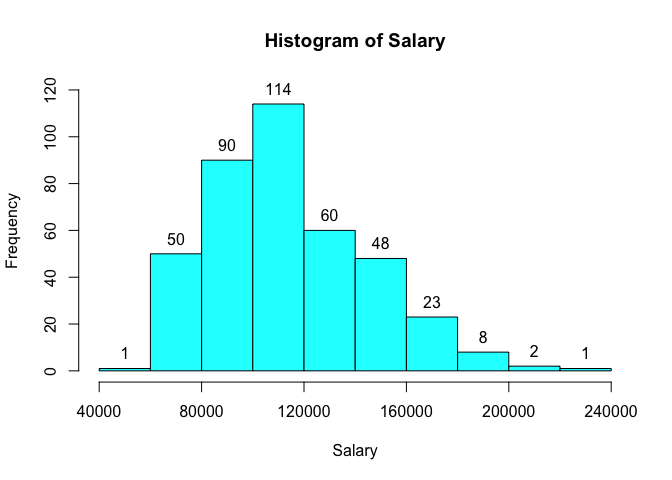

```r
hist(Salaries$salary,
     breaks = seq(40000, 240000, 20000),
     col = "cyan",
     main = "Histogram of Salary",
     xlab = "Salary",
     ylab = "Frequency",
     xlim = c(40000, 240000),
     ylim = c(0,120),
     xaxt = "n")

axis(1, at = seq(40000, 240000, 40000))

# 获取直方图的数据
hist_data <- hist(Salaries$salary,
     breaks = seq(0, 300000, 20000),
                  plot = FALSE)

# 在直方图上标注频数
text(x = hist_data$mids, y = hist_data$counts,
     labels = hist_data$counts, pos = 3, col = 1)
```

## 1.6 1.6 绘制数据框Salaries的salary的箱线图。

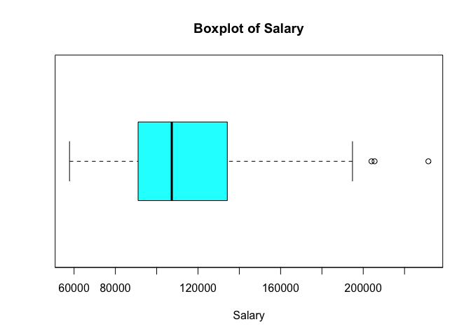

```r
boxplot(Salaries$salary,
        col = "cyan",
        main = "Boxplot of Salary",
        xlab = "Salary",
        horizontal = TRUE,
        xaxt = "n")

axis(1, at = seq(40000, 240000, 20000))
```

## 1.7 1.7 将数据框Salaries个案按照rank分组，绘制salary的分组箱线图。

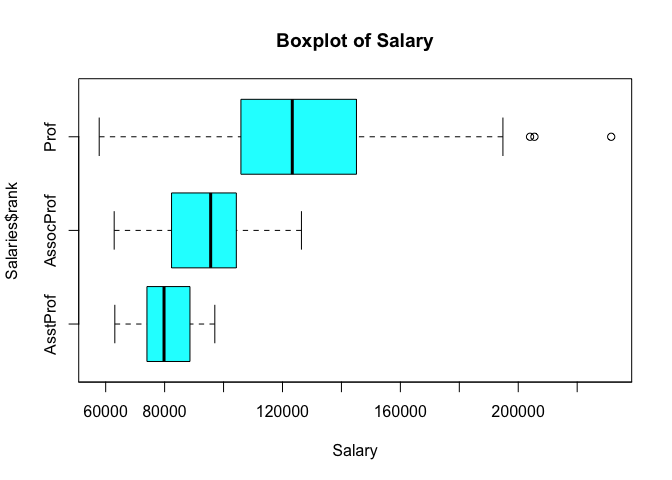

```r
boxplot(Salaries$salary ~ Salaries$rank,
        col = "cyan",
        main = "Boxplot of Salary",
        xlab = "Salary",
        horizontal = TRUE,
        xaxt = "n")

axis(1, at = seq(40000, 240000, 20000))
```

## 1.8

1.8 绘制数据框Salaries的rank的条形图。

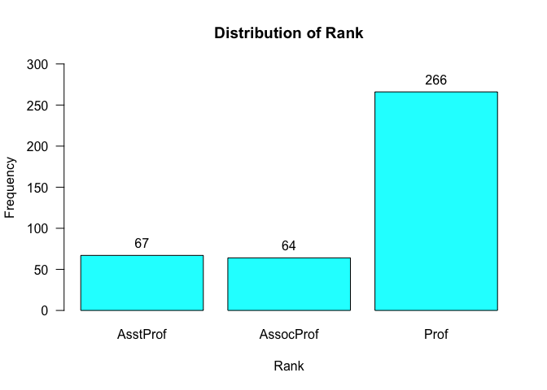

```r
counts <- table(Salaries$rank)

barplot(counts,
        col = "cyan",
        main = "Distribution of Rank",
        xlab = "Rank",
        ylab = "Frequency",
        las = 1,
        ylim = c(0,300))

# 在每个条形上标注频数
text(x = barplot(counts, plot = FALSE),
     y = counts + 0.1,
     labels = counts,
     pos = 3,
     col = "black")
```

## 1.9

1.9 绘制数据框Salaries的discipline的饼图。

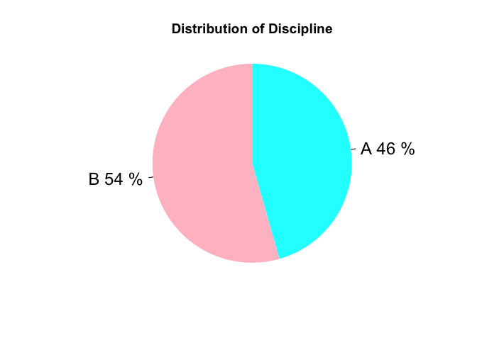

```r
counts <- table(Salaries$discipline)

pct <- round(counts/sum(counts)*100)


pie(counts,
    col = c("cyan", "pink"),
    main = "Distribution of Discipline",
    labels = paste(c("A", "B"), pct, "%"),
    clockwise = TRUE,
    radius = 1,
    cex = 1.5,
    init.angle = 90,
    border = NA)
```

## 1.10

1.10 绘制数据框Salaries的yrs.sevice和salary的散点图, 设置散点颜色和形状。

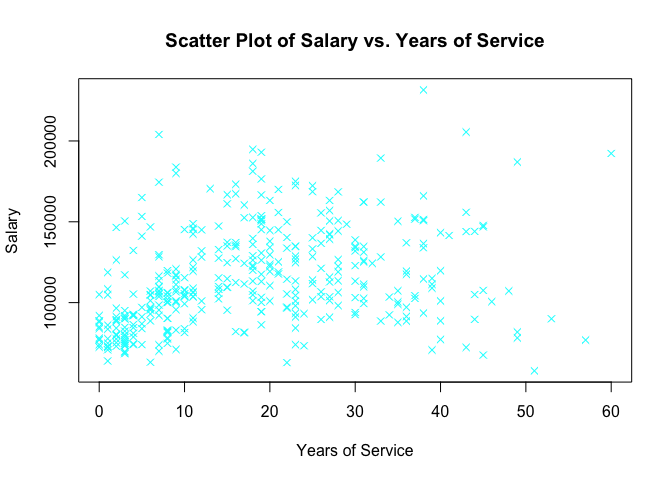

```r
plot(Salaries$yrs.service, Salaries$salary,
     col = "cyan",
     pch = 4,
     main = "Scatter Plot of Salary vs. Years of Service",
     xlab = "Years of Service",
     ylab = "Salary")
```

## 1.11

1.11 绘制数据框Salaries的yrs.since.phd和salary的散点图, 设置散点颜色和形状。

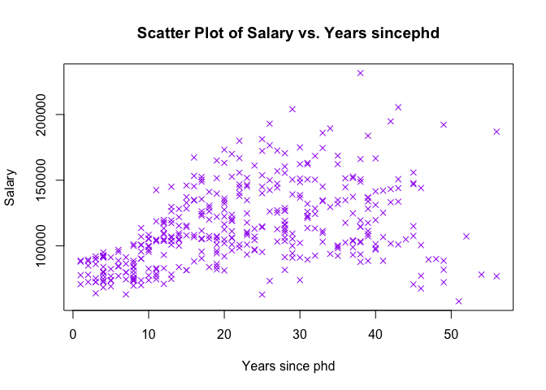

```r
plot(Salaries$yrs.since.phd, Salaries$salary,
     col = "purple",
     pch = 4,
     main = "Scatter Plot of Salary vs. Years sincephd",
     xlab = "Years since phd",
     ylab = "Salary")
```

## 1.12 1.12 利用cut()函数将数据框Salaries的salary转换成因子。

```r
Salaries$salary_cat <- cut(Salaries$salary,
                           breaks = c(50000, 100000, 150000, 200000, 250000))

table(Salaries$salary_cat)
```

```
  (5e+04,1e+05] (1e+05,1.5e+05] (1.5e+05,2e+05] (2e+05,2.5e+05]
            141             202              51               3
```

## 1.13

1.13 查看数据框Salaries的前六行、后六行。

```r
head(Salaries)
```

|  | rank | discipline | yrs.since.phd | yrs.service | sex | salary | salary_cat |
| --- | --- | --- | --- | --- | --- | --- | --- |
| 1 | Prof | B | 19 | 18 | Male | 139750 | (1e+05,1.5e+05] |
| 2 | Prof | B | 20 | 16 | Male | 173200 | (1.5e+05,2e+05] |
| 3 | AsstProf | B | 4 | 3 | Male | 79750 | (5e+04,1e+05] |
| 4 | Prof | B | 45 | 39 | Male | 115000 | (1e+05,1.5e+05] |
| 5 | Prof | B | 40 | 41 | Male | 141500 | (1e+05,1.5e+05] |
| 6 | AssocProf | B | 6 | 6 | Male | 97000 | (5e+04,1e+05] |

```r
tail(Salaries)
```

|  | rank | discipline | yrs.since.phd | yrs.service | sex | salary | salary_cat |
| --- | --- | --- | --- | --- | --- | --- | --- |
| 392 | Prof | A | 30 | 19 | Male | 151292 | (1.5e+05,2e+05] |
| 393 | Prof | A | 33 | 30 | Male | 103106 | (1e+05,1.5e+05] |
| 394 | Prof | A | 31 | 19 | Male | 150564 | (1.5e+05,2e+05] |
| 395 | Prof | A | 42 | 25 | Male | 101738 | (1e+05,1.5e+05] |
| 396 | Prof | A | 25 | 15 | Male | 95329 | (5e+04,1e+05] |
| 397 | AsstProf | A | 8 | 4 | Male | 81035 | (5e+04,1e+05] |

## 1.14

1.14 查看数据框Salaries的salary的第1个值、第2个值、第3个值。

```r
Salaries$salary[1:3]
```

```
[1] 139750 173200  79750
```

## 1.15

1.15 查看数据框Salaries的第1至3行, 第1至3列。

```r
Salaries[1:3, 1:3]
```

|  | rank | discipline | yrs.since.phd |
| --- | --- | --- | --- |
| 1 | Prof | B | 19 |
| 2 | Prof | B | 20 |
| 3 | AsstProf | B | 4 |

## 1.16

1.16 报告数据框Salaries的salary的五数概括(最小值、第1个四分位数、中位数、第3个四分位数和最大值)。

```r
fivenum(Salaries$salary)
```

```
[1]  57800  91000 107300 134185 231545
```

## 1.17

1.17 报告数据框Salaries的salary的描述性统计量(均值、中位数、标准差、偏度、峰度等)。

```r
psych::describe(Salaries$salary) %>%
  select(mean, median, sd, skew, kurtosis)
```

|  | mean | median | sd | skew | kurtosis |
| --- | --- | --- | --- | --- | --- |
| X1 | 113706.5 | 107300 | 30289.04 | 0.7091778 | 0.1814838 |

# 习题2

**绘制下列向量的直方图,为直方图填充你喜爱的颜色。**

## 2.1

2.1 生成一个服从均匀分布的向量，该向量包含1000个值。

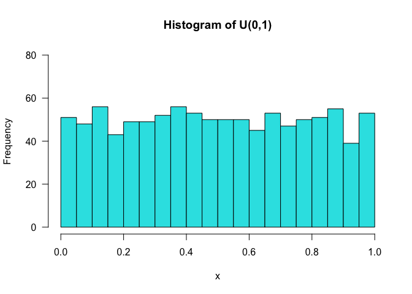

```r
set.seed(123) #设置随机数种子，保证每次运行代码生成的随机数相同
x <- runif(1000)
hist(x, breaks = 20,col = 5,
     main = "Histogram of U(0,1)",
     ylim = c(0,80),
     yaxt = "n"
     )


# 设置 Y 轴刻度
axis(side = 2, las = 1,at = seq(0, 80, 20),
     labels = seq(0, 80, 20),font = 0.5)
```

## 2.2

2.2 生成一个服从标准正态分布的向量，该向量包含1000个值。

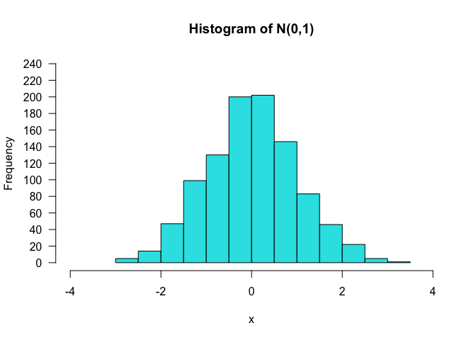

```r
set.seed(123)
x <- rnorm(1000)
hist(x, main = "Histogram of N(0,1)", col = 5,
     ylim = c(0,240),
     xlim = c(-4,4),
     yaxt = "n")

# 设置 Y 轴刻度
axis(side = 2,las = 1, at = seq(0, 240, 20),
     labels = seq(0, 240, 20),font = 0.5)
```

## 2.3

2.3 生成一个服从均值为80，标准差为5的正态分布的向量，该向量包含1000个值。

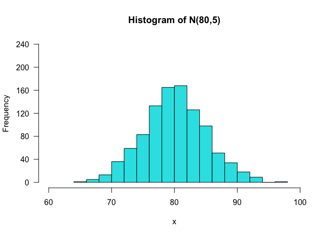

```r
set.seed(123)
x <- rnorm(1000, 80, 5)
hist(x, main = "Histogram of N(80,5)", col = 5,
     ylim = c(0,240),
     xlim = c(60,100),
     yaxt = "n")

# 设置 Y 轴刻度
axis(side = 2,las = 1, at = seq(0, 240, 40),
     labels = seq(0, 240, 40),font = 0.5)
```

## 2.4

2.4 生成一个服从自由度为5的卡方分布的向量，该向量包含1000个值。

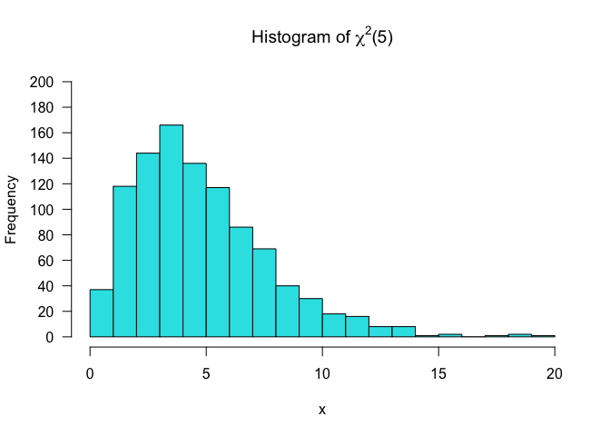

```r
set.seed(123)
x <- rchisq(1000, 5)
hist(x, col = 5, breaks = 20,
     main = expression(paste("Histogram of ",chi^2, "(5)")),
     ylim = c(0,200),
     xlim = c(0,20),
     yaxt = "n")

# 设置 Y 轴刻度
axis(side = 2, las = 1,at = seq(0, 200,20),
     labels = seq(0, 200, 20),font = 0.5)
```

## 2.5

2.5 生成一个服从自由度为5的t分布的向量，该向量包含1000个值。

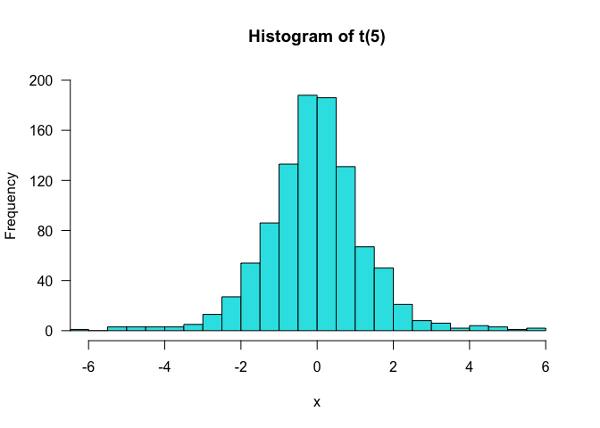

```r
set.seed(123)
x <- rt(1000, 5)
hist(x, main = "Histogram of t(5)", col = 5,
     ylim = c(0,200),
     xlim = c(-6,6),
     breaks = 20,
     yaxt = "n")

# 设置 Y 轴刻度
axis(side = 2, las = 1,at = seq(0, 200, 40),
     labels = seq(0, 200, 40),font = 0.5)
```

## 2.6

2.6 生成一个服从F(5,10)分布的向量，该向量包含1000个值。

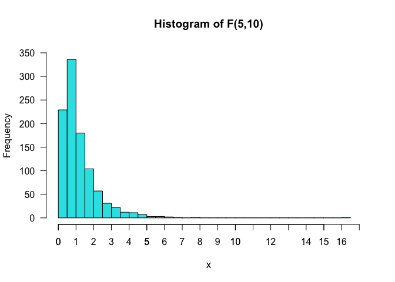

```r
set.seed(123)
x <- rf(1000, 5,10)
hist(x,breaks = 50,col = 5,
     main = "Histogram of F(5,10)",
     ylim = c(0,350),
     xlim = c(0,17),
     yaxt = "n")

# 设置 X 轴刻度
axis(side = 1,las = 1, at = seq(0, 17, 1),
     labels = seq(0, 17, 1),font = 0.5)

# 设置 Y轴刻度
axis(side = 2,las = 1, at = seq(0, 350, by = 50),
     labels = seq(0, 350, by = 50),font = 0.5)
```

# 习题3

## 3.1

```r
data(airquality)
```

3.1 利用循环语句绘制数据框airquality中的Ozone、Solar.R、Wind、Temp的箱线图。

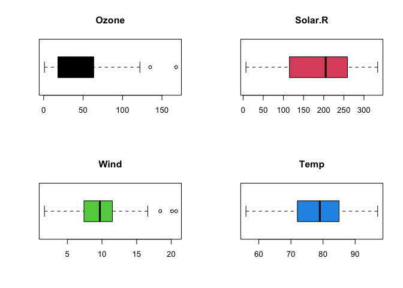

```r
par(mfrow = c(2,2))

for (i in 1:4) {
  boxplot(airquality[,i],
          main = names(airquality)[i],
          col = i,
          horizontal = TRUE)
}
```

## 3.2

3.2 利用循环语句绘制数据框airquality中的Ozone、Solar.R、Wind、Temp的直方图。

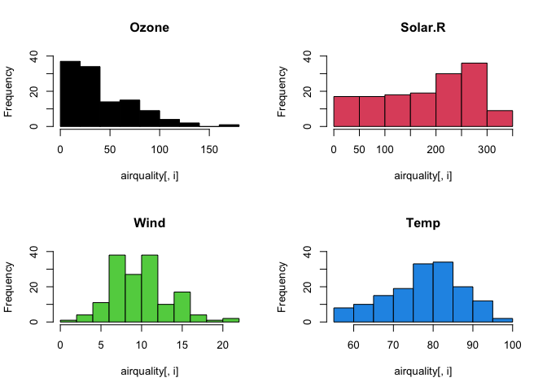

```r
par(mfrow = c(2,2))

for (i in 1:4) {
  hist(airquality[,i],
      main = names(airquality)[i],
      col = i,
      ylim = c(0,40))
  }
```